# Description of dataset

```python
ls
```

| loan_status | emp_title | emp_length | state | homeownership | annual_income | verified_income | debt_to_income | annual_income_joint | verification_income_joint | debt_to_income_joint | ... | grade | sub_grade | issue_month | initial_listing_status | disbursement_method | balance | paid_total | paid_principal | paid_interest | paid_late_fees |
| --- | --- | --- | --- | --- | --- | --- | --- | --- | --- | --- | --- | --- | --- | --- | --- | --- | --- | --- | --- | --- | --- |
| Charged Off | 6 | 6 | 7 | 7 | 7 | 7 | 7 | 1 | 1 | 1 | ... | 7 | 7 | 7 | 7 | 7 | 7 | 7 | 7 | 7 | 7 |
| Current | 8585 | 8599 | 9375 | 9375 | 9375 | 9375 | 9354 | 1399 | 1362 | 1399 | ... | 9375 | 9375 | 9375 | 9375 | 9375 | 9375 | 9375 | 9375 | 9375 | 9375 |
| Fully Paid | 419 | 420 | 447 | 447 | 447 | 447 | 445 | 59 | 57 | 59 | ... | 447 | 447 | 447 | 447 | 447 | 447 | 447 | 447 | 447 | 447 |
| In Grace Period | 62 | 63 | 67 | 67 | 67 | 67 | 66 | 17 | 16 | 17 | ... | 67 | 67 | 67 | 67 | 67 | 67 | 67 | 67 | 67 | 67 |
| Late (16-30 days) | 36 | 36 | 38 | 38 | 38 | 38 | 38 | 7 | 7 | 7 | ... | 38 | 38 | 38 | 38 | 38 | 38 | 38 | 38 | 38 | 38 |
| Late (31-120 days) | 59 | 59 | 66 | 66 | 66 | 66 | 66 | 12 | 12 | 12 | ... | 66 | 66 | 66 | 66 | 66 | 66 | 66 | 66 | 66 | 66 |

6 rows × 54 columns

```python
ls_title= df['loan_status'].unique()
```

```python
ls_title
```

```
array(['Current', 'Fully Paid', 'In Grace Period', 'Late (31-120 days)',
       'Charged Off', 'Late (16-30 days)'], dtype=object)
```

```python
import plotly.express as px
import numpy

s = df['loan_status'].value_counts() ## Counts the occurrence of unqiue elements and stores in a variable called "s" which is series type
new = pd.DataFrame({'loan_status':s.index, 'Count':s.values})
```

```python
s.values
```

```
array([9375,  447,   67,   66,   38,    7], dtype=int64)
```

```python
import plotly.express as px
import numpy

fig = px.pie(values=s.values, names=s.index, title='Percenatage of loan_status per category',color=s.index,color_discrete_sequence=px.colors.qualitative.G10)
fig.show()
```

[interactive chart not shown]

```python
states= df['state'].unique()
```

```python
states
```

```
array(['NJ', 'HI', 'WI', 'PA', 'CA', 'KY', 'MI', 'AZ', 'NV', 'IL', 'FL',
       'SC', 'CO', 'TN', 'TX', 'VA', 'NY', 'GA', 'MO', 'AR', 'MD', 'NC',
       'NE', 'WV', 'NH', 'UT', 'DE', 'MA', 'OR', 'OH', 'OK', 'SD', 'MN',
       'AL', 'WY', 'LA', 'IN', 'KS', 'MS', 'WA', 'ME', 'VT', 'CT', 'NM',
       'AK', 'MT', 'RI', 'ND', 'DC', 'ID'], dtype=object)
```

```python
amount=df.groupby('state')['loan_amount'].sum()
```

```python
amount
```

```
state
AK      632850
AL     1946550
AR      979775
AZ     4113475
CA    22073700
CO     4020525
CT     3258925
DC      394500
DE      300600
FL    11203675
GA     5545300
HI      674500
ID      636950
IL     6776600
IN     2692325
KS     1405500
KY     1509475
LA     1631175
MA     3801875
MD     3902375
ME      347275
MI     4036700
MN     2769525
MO     2651825
MS     1106850
MT      386200
NC     4809225
ND      258500
NE      758825
NH      722225
NJ     5665850
NM      695075
NV     2638750
NY    12589650
OH     5434125
OK     1448350
OR     2129450
PA     4665825
RI      751375
SC     2613900
SD      308700
TN     2651000
TX    13755275
UT      938700
VA     4465225
VT      336775
WA     3860700
WI     2028875
WV      981650
WY      312175
Name: loan_amount, dtype: int64
```

```python
import pandas as pd
import plotly.express as px
import statsmodels.formula.api as smapi
import numpy as np

fig = px.bar(df, states, amount, color=df['state'].unique(),
                 labels={
                     "states": "State",
                     "amount": "Loan Amount",
                                     },
                title="Loan Amount for every State"
                )
fig.show()
```

[interactive chart not shown]

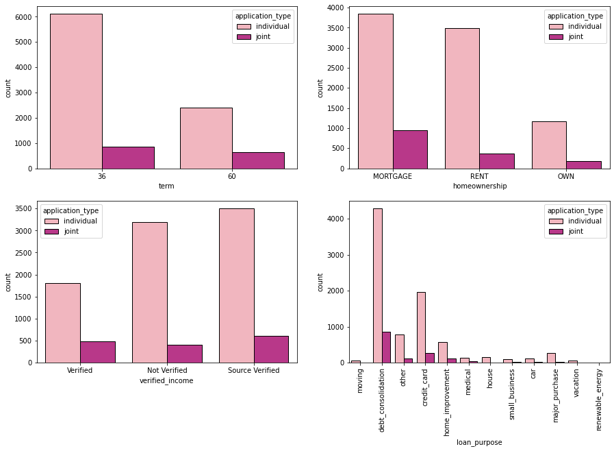

```python
plt.figure(figsize=(15, 20))

plt.subplot(4, 2, 1)
sns.countplot(x='term', data=df, hue='application_type', palette='RdPu', edgecolor='black')

plt.subplot(4, 2, 2)
sns.countplot(x='homeownership', data=df, hue='application_type', palette='RdPu', edgecolor='black')

plt.subplot(4, 2, 3)
sns.countplot(x='verified_income', data=df, hue='application_type', palette='RdPu',edgecolor='black')

plt.subplot(4, 2, 4)
g = sns.countplot(x='loan_purpose', data=df, hue='application_type', palette='RdPu',edgecolor='black')
g.set_xticklabels(g.get_xticklabels(), rotation=90);
```

```python
paidtotal=df.groupby('loan_purpose')['paid_total'].sum()
```

```python
paidtotal
```

```
loan_purpose
car                   1.880338e+05
credit_card           4.999259e+06
debt_consolidation    1.372605e+07
home_improvement      1.766449e+06
house                 4.151339e+05
major_purchase        8.362259e+05
medical               4.216902e+05
moving                1.275343e+05
other                 1.998309e+06
renewable_energy      1.468471e+04
small_business        3.676864e+05
vacation              8.128827e+04
Name: paid_total, dtype: float64
```

```python
paidprincipal=df.groupby('loan_purpose')['paid_principal'].sum()
```

```python
paidprincipal
```

```
loan_purpose
car                     136720.19
credit_card            3791547.82
debt_consolidation    10254801.85
home_improvement       1370570.81
house                   330449.70
major_purchase          673944.02
medical                 362076.41
moving                  103924.02
other                  1572277.12
renewable_energy          9332.35
small_business          271651.94
vacation                 67188.43
Name: paid_principal, dtype: float64
```

```python
paidint=df.groupby('loan_purpose')['paid_interest'].sum()
```

```python
paidint
```

```
loan_purpose
car                     51313.63
credit_card           1207487.60
debt_consolidation    3470732.04
home_improvement       395801.79
house                   84631.22
major_purchase         162251.86
medical                 59553.64
moving                  23610.29
other                  425829.13
renewable_energy         5352.36
small_business          96004.41
vacation                14099.84
Name: paid_interest, dtype: float64
```

```python
paidlate=df.groupby('loan_purpose')['paid_late_fees'].sum()
```

```python
paidlate
```

```
loan_purpose
car                     0.00
credit_card           223.73
debt_consolidation    518.93
home_improvement       76.62
house                  52.98
major_purchase         30.00
medical                60.12
moving                  0.00
other                 202.78
renewable_energy        0.00
small_business         30.00
vacation                0.00
Name: paid_late_fees, dtype: float64
```

```python
import plotly.graph_objects as go
from plotly.subplots import make_subplots

fig = make_subplots(rows=2, cols=2, start_cell="bottom-left",subplot_titles=('Paid Interest',
                                    'Paid Late','Paid Total','Paid Principal'))

fig.add_trace(go.Scatter(y=df['loan_purpose'].unique(), x=paidtotal, mode='markers'),
              row=1, col=1)

fig.add_trace(go.Scatter(y=df['loan_purpose'].unique(), x=paidprincipal, mode='markers'),
              row=1, col=2)

fig.add_trace(go.Scatter(y=df['loan_purpose'].unique(), x=paidint,mode='markers'),
              row=2, col=1)

fig.add_trace(go.Scatter(y=df['loan_purpose'].unique(), x=paidlate,mode='markers'),
              row=2, col=2)

fig.show()
```

[interactive chart not shown]

# 3rd point: Creating a feature set and create a model which predicts interest_rate using at least 2 algorithms.

```python
for col in df.columns:
    print(col)
```

```
emp_title
emp_length
state
homeownership
annual_income
verified_income
debt_to_income
annual_income_joint
verification_income_joint
debt_to_income_joint
delinq_2y
months_since_last_delinq
earliest_credit_line
inquiries_last_12m
total_credit_lines
open_credit_lines
total_credit_limit
total_credit_utilized
num_collections_last_12m
num_historical_failed_to_pay
months_since_90d_late
current_accounts_delinq
total_collection_amount_ever
current_installment_accounts
accounts_opened_24m
months_since_last_credit_inquiry
num_satisfactory_accounts
num_accounts_120d_past_due
num_accounts_30d_past_due
num_active_debit_accounts
total_debit_limit
num_total_cc_accounts
num_open_cc_accounts
num_cc_carrying_balance
num_mort_accounts
account_never_delinq_percent
tax_liens
public_record_bankrupt
loan_purpose
application_type
loan_amount
term
interest_rate
installment
grade
sub_grade
issue_month
loan_status
initial_listing_status
disbursement_method
balance
paid_total
paid_principal
paid_interest
paid_late_fees
```

```python
#Create input and output features for the models
output_features =  df[["interest_rate"]]
print(output_features)
```

```
      interest_rate
0             14.07
1             12.61
2             17.09
3              6.72
4             14.07
...             ...
9995           7.35
9996          19.03
9997          23.88
9998           5.32
9999          10.91

[10000 rows x 1 columns]
```

```python
#Selection of input features that can effect the interest rate
input_features = df[["loan_amount","term","grade","loan_purpose"]]
print(input_features)
```

```
      loan_amount  term grade        loan_purpose
0           28000    60     C              moving
1            5000    36     C  debt_consolidation
2            2000    36     D               other
3           21600    36     A  debt_consolidation
4           23000    36     C         credit_card
...           ...   ...   ...                 ...
9995        24000    36     A               other
9996        10000    36     D  debt_consolidation
9997        30000    36     E  debt_consolidation
9998        24000    36     A               other
9999        12800    36     B         credit_card

[10000 rows x 4 columns]
```

```python
#Identified categorical values
input_features["loan_purpose"].unique()
```

```
array(['moving', 'debt_consolidation', 'other', 'credit_card',
       'home_improvement', 'medical', 'house', 'small_business', 'car',
       'major_purchase', 'vacation', 'renewable_energy'], dtype=object)
```

```python
input_features["grade"].unique()
```

```
array(['C', 'D', 'A', 'B', 'F', 'E', 'G'], dtype=object)
```

```python
output_features["interest_rate"].unique()
```

```
array([14.07, 12.61, 17.09,  6.72, 13.59, 11.99,  6.71, 15.04,  9.92,
        9.43, 19.03, 28.72, 26.77, 15.05,  6.08, 11.98,  7.96,  7.34,
        5.32,  6.07, 12.62,  9.44, 20.39,  9.93, 21.45, 10.42, 18.06,
       22.91, 30.79, 17.47,  5.31,  7.97, 14.08, 19.42, 10.91, 16.02,
       13.58, 16.01, 20.  , 21.85, 10.9 , 23.87,  7.35, 23.88, 25.82,
       10.41, 18.45, 30.17, 24.85, 25.81, 24.84, 30.75, 29.69, 26.3 ,
       22.9 ,  6.  , 30.65, 30.94])
```

```python
#Applied get_dummies() method and then dropped the old columns
dummies = pd.get_dummies(input_features.grade)

merged = pd.concat([input_features, dummies], axis='columns')
merged
```

|  | loan_amount | term | grade | loan_purpose | A | B | C | D | E | F | G |
| --- | --- | --- | --- | --- | --- | --- | --- | --- | --- | --- | --- |
| 0 | 28000 | 60 | C | moving | 0 | 0 | 1 | 0 | 0 | 0 | 0 |
| 1 | 5000 | 36 | C | debt_consolidation | 0 | 0 | 1 | 0 | 0 | 0 | 0 |
| 2 | 2000 | 36 | D | other | 0 | 0 | 0 | 1 | 0 | 0 | 0 |
| 3 | 21600 | 36 | A | debt_consolidation | 1 | 0 | 0 | 0 | 0 | 0 | 0 |
| 4 | 23000 | 36 | C | credit_card | 0 | 0 | 1 | 0 | 0 | 0 | 0 |
| ... | ... | ... | ... | ... | ... | ... | ... | ... | ... | ... | ... |
| 9995 | 24000 | 36 | A | other | 1 | 0 | 0 | 0 | 0 | 0 | 0 |
| 9996 | 10000 | 36 | D | debt_consolidation | 0 | 0 | 0 | 1 | 0 | 0 | 0 |
| 9997 | 30000 | 36 | E | debt_consolidation | 0 | 0 | 0 | 0 | 1 | 0 | 0 |
| 9998 | 24000 | 36 | A | other | 1 | 0 | 0 | 0 | 0 | 0 | 0 |
| 9999 | 12800 | 36 | B | credit_card | 0 | 1 | 0 | 0 | 0 | 0 | 0 |

10000 rows × 11 columns

```python
dummies2 = pd.get_dummies(merged.loan_purpose)

merged2 = pd.concat([merged, dummies2], axis='columns')
merged2
```

|  | loan_amount | term | grade | loan_purpose | A | B | C | D | E | F | ... | debt_consolidation | home_improvement | house | major_purchase | medical | moving | other | renewable_energy | small_business | vacation |
| --- | --- | --- | --- | --- | --- | --- | --- | --- | --- | --- | --- | --- | --- | --- | --- | --- | --- | --- | --- | --- | --- |
| 0 | 28000 | 60 | C | moving | 0 | 0 | 1 | 0 | 0 | 0 | ... | 0 | 0 | 0 | 0 | 0 | 1 | 0 | 0 | 0 | 0 |
| 1 | 5000 | 36 | C | debt_consolidation | 0 | 0 | 1 | 0 | 0 | 0 | ... | 1 | 0 | 0 | 0 | 0 | 0 | 0 | 0 | 0 | 0 |
| 2 | 2000 | 36 | D | other | 0 | 0 | 0 | 1 | 0 | 0 | ... | 0 | 0 | 0 | 0 | 0 | 0 | 1 | 0 | 0 | 0 |
| 3 | 21600 | 36 | A | debt_consolidation | 1 | 0 | 0 | 0 | 0 | 0 | ... | 1 | 0 | 0 | 0 | 0 | 0 | 0 | 0 | 0 | 0 |
| 4 | 23000 | 36 | C | credit_card | 0 | 0 | 1 | 0 | 0 | 0 | ... | 0 | 0 | 0 | 0 | 0 | 0 | 0 | 0 | 0 | 0 |
| ... | ... | ... | ... | ... | ... | ... | ... | ... | ... | ... | ... | ... | ... | ... | ... | ... | ... | ... | ... | ... | ... |
| 9995 | 24000 | 36 | A | other | 1 | 0 | 0 | 0 | 0 | 0 | ... | 0 | 0 | 0 | 0 | 0 | 0 | 1 | 0 | 0 | 0 |
| 9996 | 10000 | 36 | D | debt_consolidation | 0 | 0 | 0 | 1 | 0 | 0 | ... | 1 | 0 | 0 | 0 | 0 | 0 | 0 | 0 | 0 | 0 |
| 9997 | 30000 | 36 | E | debt_consolidation | 0 | 0 | 0 | 0 | 1 | 0 | ... | 1 | 0 | 0 | 0 | 0 | 0 | 0 | 0 | 0 | 0 |
| 9998 | 24000 | 36 | A | other | 1 | 0 | 0 | 0 | 0 | 0 | ... | 0 | 0 | 0 | 0 | 0 | 0 | 1 | 0 | 0 | 0 |
| 9999 | 12800 | 36 | B | credit_card | 0 | 1 | 0 | 0 | 0 | 0 | ... | 0 | 0 | 0 | 0 | 0 | 0 | 0 | 0 | 0 | 0 |

10000 rows × 23 columns

```python
input_features_final = merged2.drop(['loan_purpose', 'grade'], axis='columns')
```

```python
input_features_final
```

|  | loan_amount | term | A | B | C | D | E | F | G | car | ... | debt_consolidation | home_improvement | house | major_purchase | medical | moving | other | renewable_energy | small_business | vacation |
| --- | --- | --- | --- | --- | --- | --- | --- | --- | --- | --- | --- | --- | --- | --- | --- | --- | --- | --- | --- | --- | --- |
| 0 | 28000 | 60 | 0 | 0 | 1 | 0 | 0 | 0 | 0 | 0 | ... | 0 | 0 | 0 | 0 | 0 | 1 | 0 | 0 | 0 | 0 |
| 1 | 5000 | 36 | 0 | 0 | 1 | 0 | 0 | 0 | 0 | 0 | ... | 1 | 0 | 0 | 0 | 0 | 0 | 0 | 0 | 0 | 0 |
| 2 | 2000 | 36 | 0 | 0 | 0 | 1 | 0 | 0 | 0 | 0 | ... | 0 | 0 | 0 | 0 | 0 | 0 | 1 | 0 | 0 | 0 |
| 3 | 21600 | 36 | 1 | 0 | 0 | 0 | 0 | 0 | 0 | 0 | ... | 1 | 0 | 0 | 0 | 0 | 0 | 0 | 0 | 0 | 0 |
| 4 | 23000 | 36 | 0 | 0 | 1 | 0 | 0 | 0 | 0 | 0 | ... | 0 | 0 | 0 | 0 | 0 | 0 | 0 | 0 | 0 | 0 |
| ... | ... | ... | ... | ... | ... | ... | ... | ... | ... | ... | ... | ... | ... | ... | ... | ... | ... | ... | ... | ... | ... |
| 9995 | 24000 | 36 | 1 | 0 | 0 | 0 | 0 | 0 | 0 | 0 | ... | 0 | 0 | 0 | 0 | 0 | 0 | 1 | 0 | 0 | 0 |
| 9996 | 10000 | 36 | 0 | 0 | 0 | 1 | 0 | 0 | 0 | 0 | ... | 1 | 0 | 0 | 0 | 0 | 0 | 0 | 0 | 0 | 0 |
| 9997 | 30000 | 36 | 0 | 0 | 0 | 0 | 1 | 0 | 0 | 0 | ... | 1 | 0 | 0 | 0 | 0 | 0 | 0 | 0 | 0 | 0 |
| 9998 | 24000 | 36 | 1 | 0 | 0 | 0 | 0 | 0 | 0 | 0 | ... | 0 | 0 | 0 | 0 | 0 | 0 | 1 | 0 | 0 | 0 |
| 9999 | 12800 | 36 | 0 | 1 | 0 | 0 | 0 | 0 | 0 | 0 | ... | 0 | 0 | 0 | 0 | 0 | 0 | 0 | 0 | 0 | 0 |

10000 rows × 21 columns

```python
input_features_final.isnull().values.any()
```

```
False
```

```python
# #Convert the output features from floats to ints as the classifier expects categorical data

# output_features['interest_rate'] = output_features['interest_rate'].astype(int)
```

```python
#Split the dataset into train and test inputs for the model
X_train, X_test, y_train, y_test = train_test_split(input_features_final,output_features,test_size = 0.3)
```

```python
#Checking the consistency of the data sets
print(X_train.shape)
print(X_test.shape)
print(y_train.shape)
print(y_test.shape)
```

```
(7000, 21)
(3000, 21)
(7000, 1)
(3000, 1)
```

```python
model_y_train = y_train["interest_rate"].astype(int)
model_y_test = y_test["interest_rate"].astype(int)
```

```python
X_train
```

|  | loan_amount | term | A | B | C | D | E | F | G | car | ... | debt_consolidation | home_improvement | house | major_purchase | medical | moving | other | renewable_energy | small_business | vacation |
| --- | --- | --- | --- | --- | --- | --- | --- | --- | --- | --- | --- | --- | --- | --- | --- | --- | --- | --- | --- | --- | --- |
| 2614 | 15000 | 36 | 1 | 0 | 0 | 0 | 0 | 0 | 0 | 0 | ... | 1 | 0 | 0 | 0 | 0 | 0 | 0 | 0 | 0 | 0 |
| 9800 | 6000 | 36 | 0 | 0 | 0 | 1 | 0 | 0 | 0 | 0 | ... | 0 | 0 | 0 | 0 | 1 | 0 | 0 | 0 | 0 | 0 |
| 2990 | 10000 | 36 | 1 | 0 | 0 | 0 | 0 | 0 | 0 | 0 | ... | 1 | 0 | 0 | 0 | 0 | 0 | 0 | 0 | 0 | 0 |
| 174 | 11000 | 36 | 0 | 0 | 0 | 1 | 0 | 0 | 0 | 0 | ... | 1 | 0 | 0 | 0 | 0 | 0 | 0 | 0 | 0 | 0 |
| 1269 | 23000 | 60 | 0 | 0 | 1 | 0 | 0 | 0 | 0 | 0 | ... | 1 | 0 | 0 | 0 | 0 | 0 | 0 | 0 | 0 | 0 |
| ... | ... | ... | ... | ... | ... | ... | ... | ... | ... | ... | ... | ... | ... | ... | ... | ... | ... | ... | ... | ... | ... |
| 9942 | 20000 | 36 | 0 | 1 | 0 | 0 | 0 | 0 | 0 | 0 | ... | 1 | 0 | 0 | 0 | 0 | 0 | 0 | 0 | 0 | 0 |
| 8204 | 35000 | 36 | 0 | 1 | 0 | 0 | 0 | 0 | 0 | 0 | ... | 0 | 0 | 0 | 0 | 0 | 0 | 0 | 0 | 0 | 0 |
| 5147 | 3600 | 36 | 1 | 0 | 0 | 0 | 0 | 0 | 0 | 0 | ... | 0 | 0 | 0 | 0 | 0 | 0 | 0 | 0 | 0 | 0 |
| 5550 | 9000 | 36 | 0 | 1 | 0 | 0 | 0 | 0 | 0 | 1 | ... | 0 | 0 | 0 | 0 | 0 | 0 | 0 | 0 | 0 | 0 |
| 7853 | 25000 | 36 | 1 | 0 | 0 | 0 | 0 | 0 | 0 | 0 | ... | 0 | 1 | 0 | 0 | 0 | 0 | 0 | 0 | 0 | 0 |

7000 rows × 21 columns

```python
y_train
```

|  | interest_rate |
| --- | --- |
| 2614 | 7.34 |
| 9800 | 17.47 |
| 2990 | 6.08 |
| 174 | 18.06 |
| 1269 | 13.58 |
| ... | ... |
| 9942 | 9.93 |
| 8204 | 10.41 |
| 5147 | 7.35 |
| 5550 | 9.43 |
| 7853 | 6.07 |

7000 rows × 1 columns

```python
model_y_train
```

```
2614     7
9800    17
2990     6
174     18
1269    13
        ..
9942     9
8204    10
5147     7
5550     9
7853     6
Name: interest_rate, Length: 7000, dtype: int32
```

```python
#Import the model (Random Forest Classifier)
model = RandomForestClassifier(bootstrap=False, max_depth=90, max_features='sqrt',
                       min_samples_split=5, n_estimators=800, random_state=0)
```

```python
model.fit(X_train, model_y_train)
```

```
RandomForestClassifier(bootstrap=False, max_depth=90, max_features='sqrt',
                       min_samples_split=5, n_estimators=800, random_state=0)
```

```python
predict = model.predict(X_test)
```

```python
predict
```

```
array([17,  7, 13, ..., 20, 26,  6])
```

```python
answer = np.round(predict, 2)
print(answer)
```

```
[17  7 13 ... 20 26  6]
```

```python
mean_squared_error(model_y_test,answer) # We can see the mean squared error is bit high
```

```
2.237
```

```python
y_test= y_test.to_numpy()
y_test = [item for sublist in y_test for item in sublist]
```

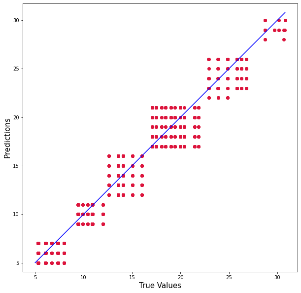

```python
plt.figure(figsize=(10,10))
plt.scatter(y_test, answer, c='crimson')

p1 = max(max(answer), max(y_test))
p2 = min(min(answer), min(y_test))
plt.plot([p1, p2], [p1, p2], 'b-')
plt.xlabel('True Values', fontsize=15)
plt.ylabel('Predictions', fontsize=15)
plt.axis('equal')
plt.show()
```

```python
#Linear Regression
model2 = LinearRegression()
```

```python
model2.fit(X_train, model_y_train)
```

```
LinearRegression()
```

```python
max(y_test)
```

```
30.79
```

```python
predict = model2.predict(X_test)
print(predict)
```

```
[18.78789991  6.24441739 13.88625366 ... 18.70045294 24.37622516
  6.20810125]
```

```python
answer = np.round(predict, 2)
print(answer)
```

```
[18.79  6.24 13.89 ... 18.7  24.38  6.21]
```

```python
y_test
```

[output not shown]

[output cut: 946 more lines]

```
 9.93,
 18.06,
 5.32,
 10.42,
 9.93,
 7.35,
 12.62,
 16.01,
 9.93,
 16.01,
 18.06,
 9.43,
 6.08,
 7.97,
 ...]
```

```python
mean_squared_error(y_test,answer)
```

```
1.4759833333333336
```

Here we can conclude that the Linear regression would work better than the Random forest classifier as the mean_squared error of linear regression is lower than the random forest algorithm.

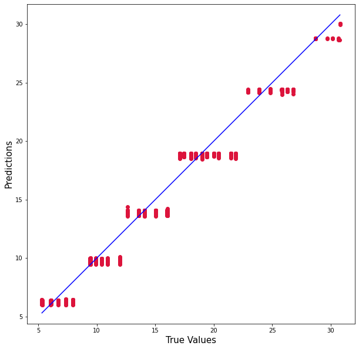

```python
plt.figure(figsize=(10,10))
plt.scatter(y_test, answer, c='crimson')


p1 = max(max(answer), max(y_test))
p2 = min(min(answer), min(y_test))
plt.plot([p1, p2], [p1, p2], 'b-')
plt.xlabel('True Values', fontsize=15)
plt.ylabel('Predictions', fontsize=15)
plt.axis('equal')
plt.show()
```

### Propose enhancements to the model if given more time

I could have used hyperparameter tuning which allows us to make use of the optimal parameters to the machine learning models which increases the performance and computaional time of the models.

### Assumptions for this model

- I have selected a set of input features that is giving the model prediction for the interest rate.
- We have also assumed that the 'grade' and 'loan_purpose' are categorical values and have converted them accordingly.